# GoBike Data Visualization

## by Victor Pham

## Investigation Overview

This presentation is designed to outline major data trends observed through data visualizations when analyzing the Go Bike program data. Key visualations will be presented on how the various parameters of the user groups affects the count, distance (km) between stations and duration of the trips (mins).

The parameters will look at the age group, weekdays, customer type, gender and user type.

## Dataset Overview

This is a dataset of the bikeshare program called Go Bike that is run in San Fransisco, California. The dataset shares individual recorded ride trips in a specific time frame.

The dataset also shares information about the time of user using the ride-share program, including gender, age and type of customer.

## Visualization 1: Univariate Exploration

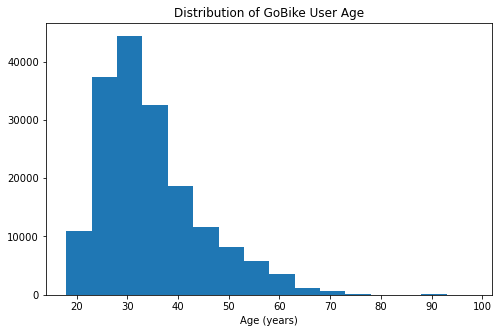

## Visualization 2: Bivariate Exploration

Another interesting trend seen in the data is that this BikeShare program is used significantly more during the week compared to the weekends. This could indicate it is used for commuting more then leisure, but it may be something worth investigating.

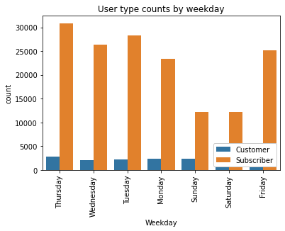

## Visualization 3: Multivariate Exploration

[figure not shown]

## Limitations

It should be noted that these are simply data visualizations that do not go into a full detailed analysis of the data, and is used a preliminary analysis to identify any trends in the data that might be worth investigating further.

Although some trends are identified in the visualizations here, they should be verified using statisical and continuous numerical analysis.